# Polski Top Wszech Czasów 2009-2014

Krzysztof Trajkowski

15 luty, 2015

## Zadanie 1

Pod adresem http://pl.wikipedia.org/wiki/Polski_Top_Wszech_Czas%C3%B3w są dostępne dane *Polski Top Wszech Czasów*. Dotyczą one notowań polskich piosenek w audycji muzycznej emitowanej na antenie Programu Trzeciego Polskiego Radia.

1. Zainstaluj pakiet *XML*,
2. Za pomocą funkcji *readHTMLTable* z pakietu *XML* wczytaj te dane (lista tabelek) do programu R.
3. Połącz tabelki (lista tabelek) dotyczące lat 2009-2014 w jedną tabele (obiekt *data.frame*).
4. Sprawdź wymiary otrzymanej tabeli (ilość wierszy i kolumn) a następnie zapisz otrzymaną tabelę do pliku .csv o nazwie baza1.

#### Polecenie 1

Użytkownicy Linuksa do poprawnej instalacji pakietu *XML* w środowisku R powinni mieć zainstalowaną w systemie operacyjnym bibliotekę *libxml2-dev*. W przypadku dystrybucji Ubuntu można to zrobić wpisująć w konsoli poniższe polecenie:

sudo apt-get install libxml2-dev

install.packages(“XML”)

#### Polecenie 2

```r
library(PogromcyDanych)
```

Wczutujemy wymagany pakiet XML:

```r
library("XML")
```

Adres strony internetowej z danymi:

```r
adres <- "http://pl.wikipedia.org/wiki/Polski_Top_Wszech_Czas%C3%B3w"
```

Wczytanie tabelek:

```r
tabelki <- readHTMLTable(adres)
```

Sprawdzenie klasy obiektu:

```r
class(tabelki)
```

```
## [1] "list"
```

#### Polecenie 3

Interesują nas tabelki o numerach od 3 do 8 czyli notowania dotyczące lat 2009-2014.

```r
tabelki[3] # rok 2009
```

```
## $`NULL`
##    Miejsce      Wykonawca                 Piosenka  Rok Zm.
## 1        1 Czesław Niemen  "Dziwny jest ten świat" 1967   0
## 2        2        Perfect          "Autobiografia" 1982   0
## 3        3           Dżem             "List do M." 1991  +9
## 4        4         Aya RL                  "Skóra" 1984 +35
## 5        5 Czesław Niemen        "Sen o Warszawie" 1966 +16
## 6        6 Marek Grechuta "Dni, których nie znamy" 1971  -1
## 7        7           Kult                 "Arahja" 1988  -4
## 8        8  Obywatel G.C.     "Nie pytaj o Polskę" 1988  +1
## 9        9      Republika            "Biała flaga" 1982  -5
## 10      10           Dżem                 "Whisky" 1985  +3
```

```r
tabelki[8] # rok 2014
```

```
## $`NULL`
##    Miejsce        Wykonawca                          Piosenka  Rok Zm.
## 1        1 Sztywny Pal Azji "Wieża radości, wieża samotności" 1987  +5
## 2        2    Obywatel G.C.              "Nie pytaj o Polskę" 1988  +2
## 3        3          Perfect                   "Autobiografia" 1982  +2
## 4        4        Republika                     "Biała flaga" 1982  -2
## 5        5              TSA                              "51" 1982  +2
## 6        6             Dżem                      "List do M." 1991  -3
## 7        7   Czesław Niemen           "Dziwny jest ten świat" 1967  -6
## 8        8             Kult                          "Arahja" 1988   0
## 9        9   Marek Grechuta          "Dni, których nie znamy" 1971   0
## 10      10            Turbo                  "Dorosłe dzieci" 1982   0
```

```r
baza1 <- do.call(rbind.data.frame, tabelki[3:8])
```

#### Polecenie 4

Kilka pierwszych wierszy.

```r
head(baza1)
```

```
##        Miejsce      Wykonawca                 Piosenka  Rok Zm.
## NULL.1       1 Czesław Niemen  "Dziwny jest ten świat" 1967   0
## NULL.2       2        Perfect          "Autobiografia" 1982   0
## NULL.3       3           Dżem             "List do M." 1991  +9
## NULL.4       4         Aya RL                  "Skóra" 1984 +35
## NULL.5       5 Czesław Niemen        "Sen o Warszawie" 1966 +16
## NULL.6       6 Marek Grechuta "Dni, których nie znamy" 1971  -1
```

```r
dim(baza1)
```

```
## [1] 60  5
```

```r
write.csv(baza1, "/home/krz/Pulpit/MOOC_zadania02/baza1.csv", row.names =FALSE)
```

## Zadanie 2

1. Otwórz w środowisku R plik baza1.csv.
2. Usuń cudzysłów z nazwach piosenek oraz znak + w kolumnie o nazwie Zm.
3. Zapisz tak przekształconą tabelę do pliku .csv o nazwie baza2.

#### Polecenie 1

Otwieramy plik baza1.csv.

```r
baza2 <- read.csv("/home/krz/Pulpit/MOOC_zadania02/baza1.csv")
```

#### Polecenie 2

Usuwamy cudzysłów w nazwach piosenek.

```r
baza2$Piosenka <- gsub("\"", "", baza2$Piosenka)
```

Usuwamy znak + który oznacza wzrost pozycji w porównaniu do notowania z poprzedniego roku.

```r
baza2$Zm. <- gsub("\\+", "", baza2$Zm.)
```

#### Polecenie 3

Kilka pierwszych wierszy.

```r
head(baza2)
```

```
##   Miejsce      Wykonawca               Piosenka  Rok Zm.
## 1       1 Czesław Niemen  Dziwny jest ten świat 1967   0
## 2       2        Perfect          Autobiografia 1982   0
## 3       3           Dżem             List do M. 1991   9
## 4       4         Aya RL                  Skóra 1984  35
## 5       5 Czesław Niemen        Sen o Warszawie 1966  16
## 6       6 Marek Grechuta Dni, których nie znamy 1971  -1
```

```r
write.csv(baza2, "/home/krz/Pulpit/MOOC_zadania02/baza2.csv", row.names =FALSE)
```

## Zadanie 3

1. Otwórz w środowisku R plik baza2.csv.
2. Dodaj do tabeli zmienną grupującą rok notowania o nazwie Rok.not. oraz zmienną grupującą jakościową Zmiana (zmiana pozycji na liście) na podstawie zmiennej o nazwie Zm. Wykorzystaj następujące wpisy: spadek, wzrost, bez zmian.
3. Zapisz tak przekształconą tabelę do pliku .csv o nazwie baza3.

#### Polecenie 1

Wczytujemy plik baza2.csv.

```r
baza3 <- read.csv("/home/krz/Pulpit/MOOC_zadania02/baza2.csv")
```

#### Polecenie 2

Nowa zmienna o nazwie Rok.not (rok notowania).

```r
Rok.not <- seq(2009, 2014, 1)
Rok.not <- rep(Rok.not, each=10)
```

Nowa zmienna o nazwie Zmiana (zmiana pozycji na liście).

```r
Zmiana <- replace(baza3$Zm., which(baza3$Zm.<0), "spadek")
Zmiana <- replace(Zmiana, which(baza3$Zm.>0), "wzrost")
Zmiana <- replace(Zmiana, which(baza3$Zm.==0), "bez zmian")
```

Dodajemy nowe zmienne grupujące o nazwach: Zmiana (zmiana pozycji na liście) i Rok.not (rok notowania) do tabeli baza2.

```r
baza3 <- baza3 %>%
  mutate(Zmiana= Zmiana, Rok.not= Rok.not)
```

#### Polecenie 3

Kilka pierwszych wierszy.

```r
head(baza3)
```

```
##   Miejsce      Wykonawca               Piosenka  Rok Zm.    Zmiana Rok.not
## 1       1 Czesław Niemen  Dziwny jest ten świat 1967   0 bez zmian    2009
## 2       2        Perfect          Autobiografia 1982   0 bez zmian    2009
## 3       3           Dżem             List do M. 1991   9    wzrost    2009
## 4       4         Aya RL                  Skóra 1984  35    wzrost    2009
## 5       5 Czesław Niemen        Sen o Warszawie 1966  16    wzrost    2009
## 6       6 Marek Grechuta Dni, których nie znamy 1971  -1    spadek    2009
```

Zapisujemy tabelę baza2 do pliku .csv o nazwie baza3.

```r
write.csv(baza3, "/home/krz/Pulpit/MOOC_zadania02/baza3.csv", row.names =FALSE)
```

## Zadanie 4

1. Otwórz w środowisku R plik baza3.csv.
2. Sprawdź ile było piosenek w pierwszej dziesiątce w podziale na dekadę w której powstawały. Wyniki przedstaw na wykresie paskowym.
3. Sprawdź ile razy wykonawcy byli notowani w pierwszej dziesiątce. Dodatkowo nanieś na wykres otrzymane liczebności.
4. Sprawdź ile razy piosenki były notowane w pierwszej dziesiątce.
5. Przedstaw w sposób graficzny (wykres paskowy) podsumowanie polskiego topu wszechczasów. Uwzględnij takie zmienne jak: dekada, Piosenka, Wykonawca.

#### Polecenie 1

```r
lp3top <- read.csv("/home/krz/Pulpit/MOOC_zadania02/baza3.csv")
```

#### Polecenie 2

Nowa zmienna dekada.

```r
lp3top$Rok <- as.character(lp3top$Rok)
dekada <- replace(lp3top$Rok, grep("^196", lp3top$Rok),60)
dekada <- replace(dekada, grep("^197", lp3top$Rok),70)
dekada <- replace(dekada, grep("^198", lp3top$Rok),80)
dekada <- replace(dekada, grep("^199", lp3top$Rok),90)
```

Do zboru danych (tabela lp3top) dodajemy zmienną dekada.

```r
lp3top <- lp3top %>%
  mutate(dekada= dekada)
head(lp3top)
```

```
##   Miejsce      Wykonawca               Piosenka  Rok Zm.    Zmiana Rok.not
## 1       1 Czesław Niemen  Dziwny jest ten świat 1967   0 bez zmian    2009
## 2       2        Perfect          Autobiografia 1982   0 bez zmian    2009
## 3       3           Dżem             List do M. 1991   9    wzrost    2009
## 4       4         Aya RL                  Skóra 1984  35    wzrost    2009
## 5       5 Czesław Niemen        Sen o Warszawie 1966  16    wzrost    2009
## 6       6 Marek Grechuta Dni, których nie znamy 1971  -1    spadek    2009
##   dekada
## 1     60
## 2     80
## 3     90
## 4     80
## 5     60
## 6     70
```

Zpisujemy tabele fo pliku csv.

```r
write.csv(lp3top, "/home/krz/Pulpit/MOOC_zadania02/lp3top.csv", row.names =FALSE)
```

Sprawdzamy ile było piosenek notowanych w pierwszej dziesiątce ale w podziale na dekady w których powstawały. Dodatkowo dane sortujemy.

```r
p01 <- lp3top %>%
  group_by(dekada) %>%
  summarize(ilość=n()) %>%
  arrange(ilość)
p01
```

```
## Source: local data frame [4 x 2]
##
##   dekada ilość
## 1     70     6
## 2     60     7
## 3     90     9
## 4     80    38
```

Wykres paskowy.

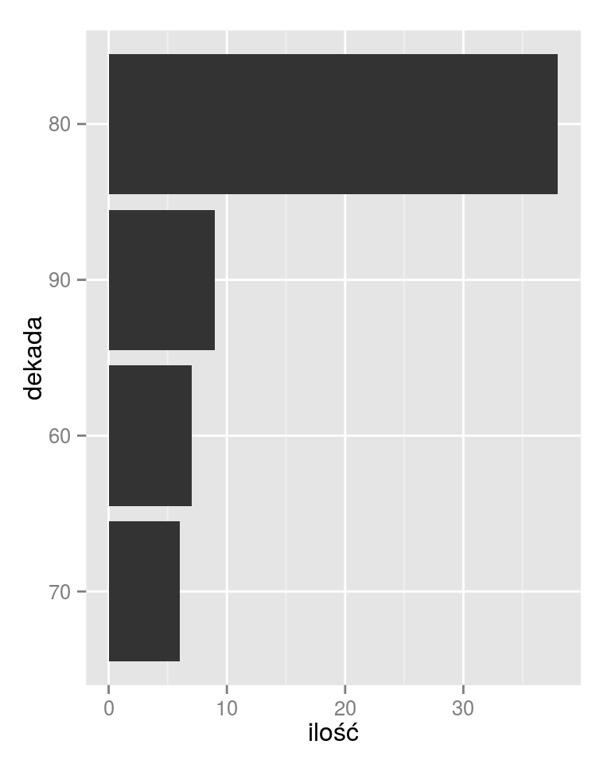

```r
plot01 <- ggplot(p01,aes(x= dekada, y= ilość))+
  geom_bar(stat = "identity")+
  scale_x_discrete(limit =p01$dekada,labels =p01$dekada)+
  coord_flip()
plot01
```

Najczęściej w pierwszej dziesiątce są piosenki które powstały w latach **osiemdziesiątych** w zestawieniu Polski Top Wszech Czasów 2009-2014 .

#### Polecenie 3

```r
p03 <- lp3top %>%
  group_by(Wykonawca) %>%
  summarize(ilość=n()) %>%
  arrange(ilość)
p03
```

```
## Source: local data frame [12 x 2]
##
##           Wykonawca ilość
## 1   Grzegorz Turnau     1
## 2            Aya RL     2
## 3             Turbo     2
## 4  Sztywny Pal Azji     4
## 5               TSA     4
## 6    Marek Grechuta     6
## 7     Obywatel G.C.     6
## 8           Perfect     6
## 9         Republika     6
## 10   Czesław Niemen     7
## 11             Dżem     7
## 12             Kult     9
```

Wykres paskowy.

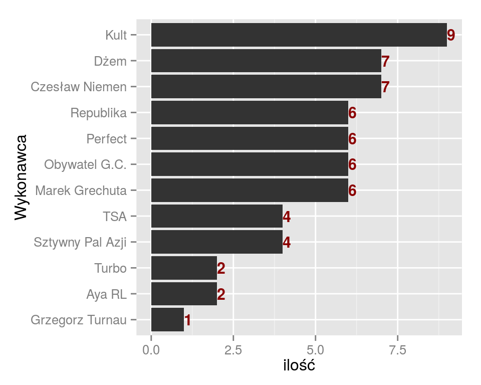

```r
plot03 <- ggplot(p03,aes(x= Wykonawca, y= ilość))+
  geom_bar(stat = "identity")+
  scale_x_discrete(limit =p03$Wykonawca,labels =p03$Wykonawca)+
  geom_text(data = p03, aes(label = ilość, y = ilość), size= 4,color= "darkred", hjust=0, vjust=0.5, fontface="bold")+
  coord_flip()
plot03
```

Najczęściej w pierwszej dziesiątce w zestawieniu Polski Top Wszech Czasów są piosenki zespołu **Kult** które powstały w latach osiemdziesiątych i dziewięćdziesiątych.

#### Polecenie 4

```r
p04 <- lp3top %>%
  group_by(Piosenka) %>%
  summarize(ilość=n()) %>%
  arrange(ilość)
p04
```

```
## Source: local data frame [16 x 2]
##
##                           Piosenka ilość
## 1                           Bracka     1
## 2                           Do Ani     1
## 3                  Sen o Warszawie     1
## 4                           Whisky     1
## 5                   Dorosłe dzieci     2
## 6                           Polska     2
## 7                            Skóra     2
## 8                               51     4
## 9  Wieża radości, wieża samotności     4
## 10                          Arahja     6
## 11                   Autobiografia     6
## 12                     Biała flaga     6
## 13          Dni, których nie znamy     6
## 14           Dziwny jest ten świat     6
## 15                      List do M.     6
## 16              Nie pytaj o Polskę     6
```

Wykres paskowy.

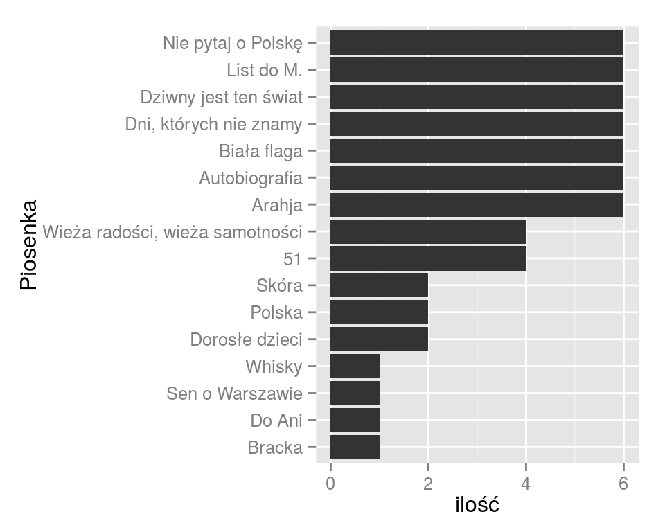

```r
plot04 <- ggplot(p04,aes(x= Piosenka, y= ilość))+
  geom_bar(stat = "identity")+
  scale_x_discrete(limit =p04$Piosenka,labels =p04$Piosenka)+
  coord_flip()
plot04
```

#### Polecenie 5

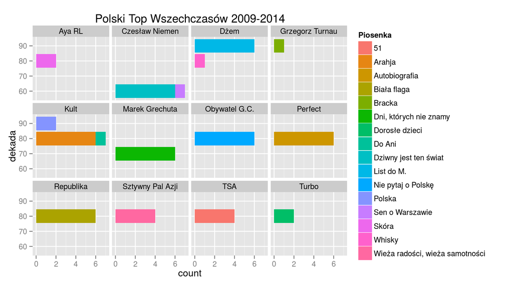

```r
plot05 <- ggplot(lp3top,aes(x= dekada, fill=Piosenka))+
  geom_bar()+facet_wrap(~Wykonawca)+
  coord_flip()+
  ggtitle("Polski Top Wszechczasów 2009-2014")
plot05
```

Tylko zespół Kult w pierwszej dziesiątce ma 3 swoje piosenki. Czesław Niemen i zespół Dżem po dwie. Pozostali wykonawcy mają po jednym utworze.